# Factors that might contribute to No Show Appointment

## by Oluwatosin Durodola

## Investigation Overview

In this investigation, I waited to look at some features that could be used to predict patients from not showing up for their appointment. The main focus was on waiting days (schedule date to appointment date) and age.

## Dataset Overview

There are 110,527 patients in the dataset with 17 features (the actual 14 features - `patientid`, `appointmentid`, `gender`, `schedule_date`, `appointment_date`, `age`, `neighbourhood`, `scholarship`, `hypertension`, `diabetes`, `alcoholism`, `handicap`, `sms_received`, `no_show`and additional 3 features created by me - `waiting days`, `appointment_day`, and `age_group`). Six data points were removed from the analysis due to inconsistencies or missing information.

## Frequency of Patients who showed up or not

The No show variable in the dataset is a question that take on a Yes or No value to answer if the patient showed up or not; the `Yes` value represent the patient who missed or didn't show up for their appointment while the `No` value represent the patient who showed up for their appointment. There are about 80% (88,207) out of over 110,521 patients who showed up for their appointment while the remaining 20% (22,314) didn't.

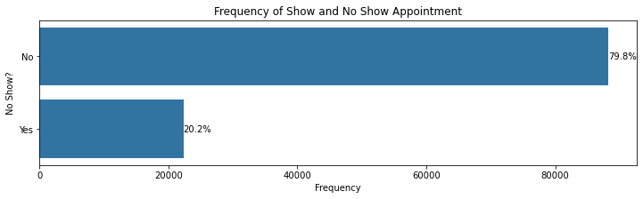

## Distribution of Waiting Days (Schedule Date to Appointment Date)

Waiting days in the dataset take on a large range of values, from 0 (same day) being the no wait to about 179 being the highest. It has a long-tailed distribution, with a lot of patients on the low waiting days end, and few on the high waiting days end. When on plotted xlim of 0 to 40, the waiting days distribution looks roughly multimodal, with peaks around 3, 5, 8 and 15 after a steep fall frequency of patients. It was also clear that as waiting days increases, the number of patients also reduced in number.

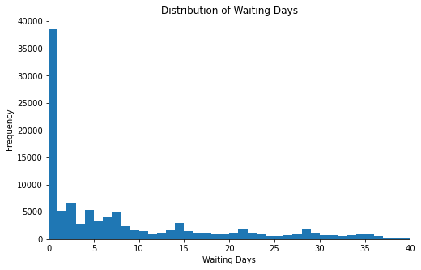

## Distribution of Age

Age in the dataset takes values of 0 to 115. Age has a long-tailed distribution, with a lot of patients on the lower age end, and few on the higher age end, it seems to be multimodal with the highest peak around 0 and 2, After ward, there is a steep fall in frequency rather than a smooth ramp down.

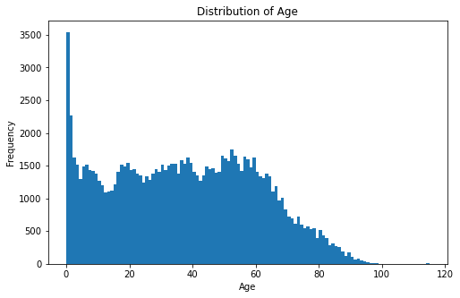

## Waiting Days vs Age

As the count of patients in the cell reduce the color in the heatmap gets brighter and moves from blue to yellow.

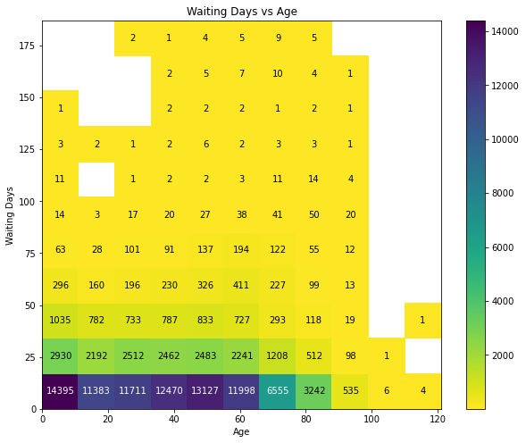

## Waiting Days by No Show Variable

Waiting days by no show variable seems affect the decision of patients in showing up compare to other categorical variables. There are about 8 average days for patients who showed up compare to patients who doesn't show up with average days of 16.

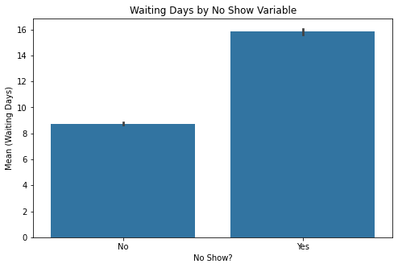

## Waiting Days by No_show and Gender

Even this still shows that the avearge waiting days of those who did not show up for their appointment by gender are still of the same value from the previous plot above falling between 15 and 16 average waiting days for both male and female.

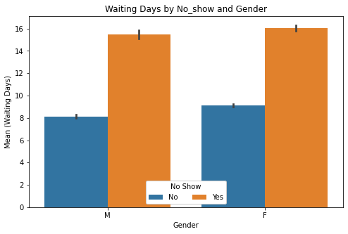